# Location-intelligentieanalyse — Gents retailnetwerk

Ruimtelijke demo met echte Gentse wijkgrenzen

Dr. Kuralarasan Kumar

09 June 2026

## Overzicht

Deze analyse plaatst een **realistisch synthetisch netwerk van 65 Delhaize-winkels binnen de echte grenzen van Gent**, op basis van de officiële polygonen van de Gentse *stadswijken*. De winkellocaties, winkelformaten en verzorgingsgebied- variabelen zijn gesimuleerd zodat ze aansluiten bij de echte stedelijke geografie van Gent: dense buurten rond het historisch centrum, residentiële zones in het zuiden en westen, studentenbuurten rond UGent-campussen en meer perifere wijken.

De demo toont drie analytische onderdelen:

1. **Modellering van winkelprestatie** — OLS-regressie van wekelijkse omzet op socio-economische, structurele en bereikbaarheidsvariabelen
2. **MAUP (Modifiable Areal Unit Problem; aanpasbaar ruimtelijk eenheidsprobleem)** — hoe regressiecoëfficiënten veranderen wanneer het verzorgingsgebied anders wordt afgebakend
3. **Vergelijking van ruimtelijke eenheden** — puntniveau (winkel), buffer/verzorgingsgebied en wijkpolygonen, weergegeven op echte kaarten

## 1. Gentse wijkgrenzen laden

```r
# Shapefile zoeken — werkt vanuit RStudio en Rscript
# knitr zet de werkmap tijdens knit naar de map van dit Rmd-bestand
ghent_path <- normalizePath(
    file.path(getwd(), "../../../data/stadswijken-gent.shp"),
    mustWork = FALSE
)
if (!file.exists(ghent_path)) {
    ghent_path <- "C:/Users/kukumar/OneDrive - UGent/My Projects/Data Annonymization/data/stadswijken-gent.shp"
}
cat("Shapefile:", ghent_path, "\n")
```

```
## Shapefile: C:/Users/kukumar/OneDrive - UGent/My Projects/Data Annonymization/data/stadswijken-gent.shp
```

```r
ghent_wgs <- st_read(ghent_path, quiet = TRUE) # WGS84 bewaren voor kaarten
ghent <- st_transform(ghent_wgs, 31370) # Belgische Lambert 72 (meter)
cat("Districten (naam):", paste(sort(unique(ghent$naam)), collapse = ", "), "\n")
```

```
## Districten (naam): Binnenstad, Kernstad, Noordoost, Noordwest, Oost, West, Zuid
```

```r
cat("Wijken:", nrow(ghent), "polygonen\n")
```

```
## Wijken: 25 polygonen
```

```r
# Oppervlakte berekenen
ghent$area_km2 <- as.numeric(st_area(ghent$geometry)) / 1e6

# Socio-economische parameters per wijk toekennen
# Gebaseerd op Gentse geografie: Binnenstad/Kernstad = dens, veel studenten
# Zuid/Noordwest = hogere inkomens; Oost/Noordoost = lagere densiteit
nr <- nrow(ghent)

base_density <- ifelse(ghent$naam == "Binnenstad", 8200,
    ifelse(ghent$naam == "Kernstad", 5500,
        ifelse(ghent$naam == "Zuid", 2800,
            ifelse(ghent$naam == "West", 2200,
                ifelse(ghent$naam %in% c("Noordoost", "Noordwest"), 1400, 950)
            )
        )
    )
)
ghent$nb_pop_density <- pmax(300, round(base_density + rnorm(nr, 0, 380)))

base_income <- ifelse(ghent$naam == "Binnenstad", 88,
    ifelse(ghent$naam == "Kernstad", 93,
        ifelse(ghent$naam %in% c("Zuid", "Noordwest"), 108,
            ifelse(ghent$naam == "West", 103, 97)
        )
    )
)
ghent$nb_income_index <- round(pmax(72, pmin(138, base_income + rnorm(nr, 0, 7))), 1)

base_students <- ifelse(ghent$naam == "Binnenstad", 28,
    ifelse(ghent$naam == "Kernstad", 20,
        ifelse(ghent$naam %in% c("Zuid", "West"), 10, 6)
    )
)
ghent$nb_pct_students <- round(pmax(2, pmin(35, base_students + rnorm(nr, 0, 4))), 1)

base_elderly <- ifelse(ghent$naam == "Binnenstad", 14,
    ifelse(ghent$naam == "Kernstad", 16,
        ifelse(ghent$naam %in% c("Zuid", "West"), 21, 25)
    )
)
ghent$nb_pct_over65 <- round(pmax(8, pmin(38, base_elderly + rnorm(nr, 0, 4))), 1)

kable(
    ghent |> st_drop_geometry() |>
        select(
            wijk, naam, area_km2, nb_pop_density, nb_income_index,
            nb_pct_students, nb_pct_over65
        ) |>
        mutate(area_km2 = round(area_km2, 2)) |>
        arrange(naam, wijk),
    caption = "Gentse wijken: socio-economische profielen per district"
)
```

Gentse wijken: socio-economische profielen per district

| wijk | naam | area_km2 | nb_pop_density | nb_income_index | nb_pct_students | nb_pct_over65 |
| --- | --- | --- | --- | --- | --- | --- |
| Binnenstad | Binnenstad | 2.67 | 8920 | 92.6 | 25.8 | 16.6 |
| Brugse Poort - Rooigem | Kernstad | 2.54 | 4573 | 87.9 | 23.7 | 21.6 |
| Elisabethbegijnhof - Prinsenhof - Papegaai - Sint-Michiels | Kernstad | 0.94 | 5996 | 81.0 | 18.5 | 18.4 |
| Macharius - Heirnis | Kernstad | 0.74 | 6074 | 97.9 | 22.7 | 17.0 |
| Rabot - Blaisantvest | Kernstad | 0.86 | 5742 | 94.4 | 25.2 | 21.6 |
| Sluizeken - Tolhuis - Ham | Kernstad | 1.25 | 6021 | 90.0 | 21.3 | 18.3 |
| Watersportbaan - Ekkergem | Kernstad | 3.68 | 5654 | 88.5 | 20.4 | 11.6 |
| Dampoort | Noordoost | 1.43 | 1376 | 100.5 | 7.1 | 20.2 |
| Gentse Kanaaldorpen en -zone | Noordoost | 41.48 | 1349 | 97.3 | 3.1 | 28.3 |
| Oostakker | Noordoost | 10.71 | 2167 | 92.7 | 2.0 | 24.5 |
| Sint-Amandsberg | Noordoost | 6.58 | 1294 | 80.1 | 11.6 | 28.7 |
| Bloemekenswijk | Noordwest | 1.67 | 1335 | 118.1 | 8.5 | 19.2 |
| Muide - Meulestede - Afrikalaan | Noordwest | 1.51 | 723 | 102.3 | 5.6 | 20.5 |
| Wondelgem | Noordwest | 9.21 | 1902 | 98.4 | 8.9 | 20.6 |
| Gentbrugge | Oost | 4.74 | 910 | 100.2 | 7.1 | 31.1 |
| Ledeberg | Oost | 1.50 | 842 | 94.5 | 7.3 | 23.1 |
| Moscou - Vogelhoek | Oost | 1.33 | 1190 | 100.2 | 8.6 | 21.5 |
| Oud Gentbrugge | Oost | 1.49 | 735 | 95.2 | 2.9 | 28.1 |
| Drongen | West | 25.61 | 2083 | 106.0 | 5.8 | 17.6 |
| Mariakerke | West | 8.24 | 3069 | 97.5 | 10.7 | 20.1 |
| Nieuw Gent - UZ | Zuid | 3.97 | 2764 | 115.2 | 10.4 | 21.4 |
| Sint-Denijs-Westrem - Afsnee | Zuid | 8.50 | 1791 | 113.3 | 14.2 | 23.6 |
| Stationsbuurt-Noord | Zuid | 2.19 | 3262 | 105.0 | 6.2 | 21.3 |
| Stationsbuurt-Zuid | Zuid | 2.67 | 2272 | 102.0 | 12.3 | 20.3 |
| Zwijnaarde | Zuid | 12.20 | 2938 | 95.7 | 16.3 | 22.9 |

```r
# Socio-economische kolommen toevoegen aan WGS84-versie voor kaarten
nb_cols <- c("nb_pop_density", "nb_income_index", "nb_pct_students", "nb_pct_over65", "area_km2")
ghent_wgs <- ghent_wgs |>
    mutate(!!!setNames(
        lapply(nb_cols, function(col) ghent[[col]]),
        nb_cols
    ))
```

## 2. Synthetische winkels in Gent plaatsen

Voor de demo simuleren we **65 winkels** met een plausibele mix van formaten en een ruimtelijke spreiding die past bij Gent: Shop&Go meer rond centrum en stations, Proxy Delhaize in binnenstedelijke woonbuurten en AD Delhaize vaker aan de stedelijke rand.

```r
n <- 65

# Polygonen wegen op basis van bevolkingsdichtheid
nb_weights <- ghent$nb_pop_density / sum(ghent$nb_pop_density)
nb_sample <- sample(seq_len(nrow(ghent)), size = n, replace = TRUE, prob = nb_weights)

# Eén willekeurig punt per winkel trekken binnen het gekozen polygoon
store_pts <- map_dfr(seq_len(n), function(i) {
    poly <- ghent[nb_sample[i], ]
    pt <- tryCatch(
        st_sample(poly, size = 1, type = "random"),
        error = function(e) st_centroid(poly$geometry)
    )
    coords <- st_coordinates(pt[[1]])
    tibble(x = coords[1], y = coords[2], nb_index = nb_sample[i])
})

# Omzetten naar sf
stores_sf <- st_as_sf(store_pts, coords = c("x", "y"), crs = 31370)

# Formaat toekennen: dichtere wijken -> meer kans op Shop&Go
density_rank <- rank(ghent$nb_pop_density[nb_sample]) / n
formats <- ifelse(density_rank > 0.72,
    sample(c("Shop&Go", "Proxy Delhaize"), n, replace = TRUE, prob = c(0.55, 0.45)),
    ifelse(density_rank > 0.35,
        sample(c("Proxy Delhaize", "AD Delhaize", "Shop&Go"), n,
            replace = TRUE,
            prob = c(0.55, 0.30, 0.15)
        ),
        sample(c("AD Delhaize", "Proxy Delhaize"), n, replace = TRUE, prob = c(0.65, 0.35))
    )
)

# Wijkkenmerken koppelen
nb_df <- ghent |>
    st_drop_geometry() |>
    select(wijk, naam, nb_pop_density, nb_income_index, nb_pct_students, nb_pct_over65)
store_nb <- nb_df[nb_sample, ]

# Structurele winkelvariabelen
floor_area_m2 <- round(
    ifelse(formats == "AD Delhaize", pmax(900, pmin(3800, rnorm(n, 2200, 450))),
        ifelse(formats == "Proxy Delhaize", pmax(180, pmin(1400, rnorm(n, 580, 160))),
            pmax(80, pmin(320, rnorm(n, 115, 35)))
        )
    )
)

catchment_r_m <- ifelse(formats == "AD Delhaize", 1500,
    ifelse(formats == "Proxy Delhaize", 800, 400)
)

parking_spaces <- round(
    ifelse(formats == "AD Delhaize", pmax(60, pmin(400, rnorm(n, 220, 65))),
        ifelse(formats == "Proxy Delhaize", pmax(0, pmin(110, rnorm(n, 32, 18))),
            pmax(0, pmin(25, rnorm(n, 4, 6)))
        )
    )
)

near_junction <- rbinom(n, 1, ifelse(formats == "AD Delhaize", 0.62,
    ifelse(formats == "Proxy Delhaize", 0.32, 0.18)
))
near_transport <- rbinom(n, 1, ifelse(formats == "Shop&Go", 0.58,
    ifelse(formats == "Proxy Delhaize", 0.28, 0.09)
))

# Concurrentenaantal uit de feitelijke afstandsmatrix tussen winkels
coords_mat <- st_coordinates(stores_sf)
dist_m <- as.matrix(dist(coords_mat))
diag(dist_m) <- NA
competitor_count <- apply(dist_m, 1, function(d) sum(d < 1000, na.rm = TRUE))

retail_density <- pmin(160, rpois(n, pmax(3, 0.015 * store_nb$nb_pop_density)))
car_ownership <- round(pmax(48, pmin(90, rnorm(n, 82 - 0.003 * store_nb$nb_pop_density, 6))), 1)

# Onderliggend data-genererend proces
base <- ifelse(formats == "AD Delhaize", 270, ifelse(formats == "Proxy Delhaize", 88, 26))

weekly_turnover <- round(pmax(
    8,
    base +
        0.018 * store_nb$nb_pop_density +
        0.85 * store_nb$nb_income_index +
        0.45 * store_nb$nb_pct_students +
        0.28 * store_nb$nb_pct_over65 +
        -13.5 * competitor_count +
        0.16 * retail_density +
        18.5 * near_junction +
        23.0 * near_transport +
        0.11 * parking_spaces +
        -0.28 * car_ownership +
        0.042 * floor_area_m2 +
        rnorm(n, 0, 18)
), 1)

stores <- stores_sf |>
    mutate(
        store_id            = sprintf("GNT%02d", seq_len(n)),
        format              = formats,
        neighbourhood       = store_nb$wijk,
        district            = store_nb$naam,
        floor_area_m2,
        catchment_r_m,
        pop_density         = store_nb$nb_pop_density,
        income_index        = store_nb$nb_income_index,
        pct_students        = store_nb$nb_pct_students,
        pct_over65          = store_nb$nb_pct_over65,
        car_ownership,
        competitor_count,
        retail_density,
        near_major_junction = near_junction,
        near_transport_hub  = near_transport,
        parking_spaces,
        weekly_turnover
    )

kable(
    stores |> st_drop_geometry() |>
        group_by(format) |>
        summarise(
            n = n(),
            `Gem. omzet (k€/week)` = round(mean(weekly_turnover), 1),
            `Gem. oppervlakte (m2)` = round(mean(floor_area_m2)),
            `Gem. concurrenten` = round(mean(competitor_count), 1),
            `% nabij transport` = round(mean(near_transport_hub) * 100)
        ),
    caption = "Samenvatting van het winkelnetwerk per formaat (Gent, n=65)"
)
```

Samenvatting van het winkelnetwerk per formaat (Gent, n=65)

| format | n | Gem. omzet (k€/week) | Gem. oppervlakte (m2) | Gem. concurrenten | % nabij transport |
| --- | --- | --- | --- | --- | --- |
| AD Delhaize | 26 | 468.2 | 2088 | 5.7 | 4 |
| Proxy Delhaize | 22 | 193.5 | 550 | 8.0 | 23 |
| Shop&Go | 17 | 148.0 | 119 | 8.8 | 59 |

## 3. Kaarten

### 3.1 Winkellocaties per formaat

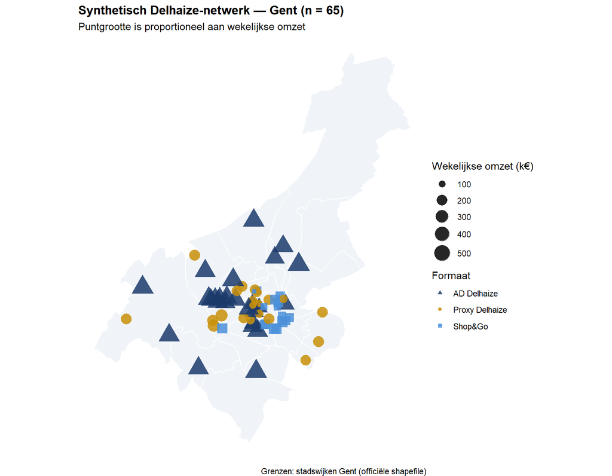

Synthetisch Delhaize-winkelnetwerk — Gent

```r
stores_wgs <- st_transform(stores, 4326)

ggplot() +
    geom_sf(data = ghent_wgs, fill = "#F0F4F8", colour = "white", linewidth = 0.5) +
    geom_sf(
        data = stores_wgs,
        aes(colour = format, shape = format, size = weekly_turnover), alpha = 0.85
    ) +
    scale_colour_manual(
        values = c(
            "AD Delhaize" = "#1B3A6B",
            "Proxy Delhaize" = "#C8900A", "Shop&Go" = "#4A90D9"
        ),
        name = "Formaat"
    ) +
    scale_shape_manual(
        values = c("AD Delhaize" = 17, "Proxy Delhaize" = 16, "Shop&Go" = 15),
        name = "Formaat"
    ) +
    scale_size_continuous(name = "Wekelijkse omzet (k€)", range = c(2, 8)) +
    labs(
        title = "Synthetisch Delhaize-netwerk — Gent (n = 65)",
        subtitle = "Puntgrootte is proportioneel aan wekelijkse omzet",
        caption = "Grenzen: stadswijken Gent (officiële shapefile)"
    ) +
    theme_void(base_size = 11) +
    theme(legend.position = "right", plot.title = element_text(face = "bold", size = 13))
```

### 3.2 Bevolkingsdichtheid per wijk

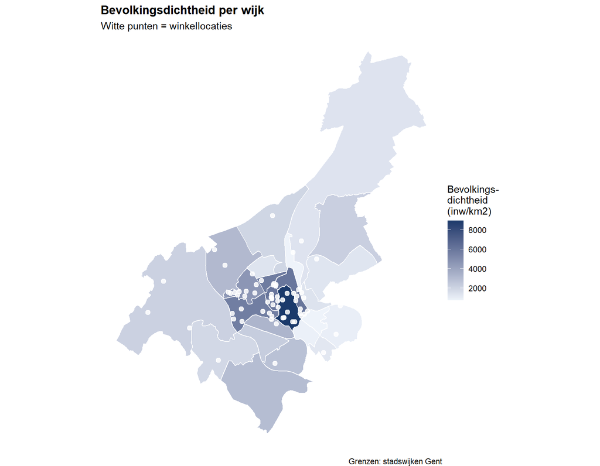

Bevolkingsdichtheid met winkels als overlay

```r
ggplot() +
    geom_sf(data = ghent_wgs, aes(fill = nb_pop_density), colour = "white", linewidth = 0.4) +
    geom_sf(
        data = stores_wgs, colour = "white", fill = "white",
        shape = 21, size = 2, stroke = 0.6, alpha = 0.85
    ) +
    scale_fill_gradient(low = "#EEF3FA", high = "#1B3A6B", name = "Bevolkings-\ndichtheid\n(inw/km2)") +
    labs(
        title = "Bevolkingsdichtheid per wijk",
        subtitle = "Witte punten = winkellocaties",
        caption = "Grenzen: stadswijken Gent"
    ) +
    theme_void(base_size = 11) +
    theme(plot.title = element_text(face = "bold", size = 13))
```

### 3.3 Verzorgingsgebiedbuffers — MAUP visueel gemaakt

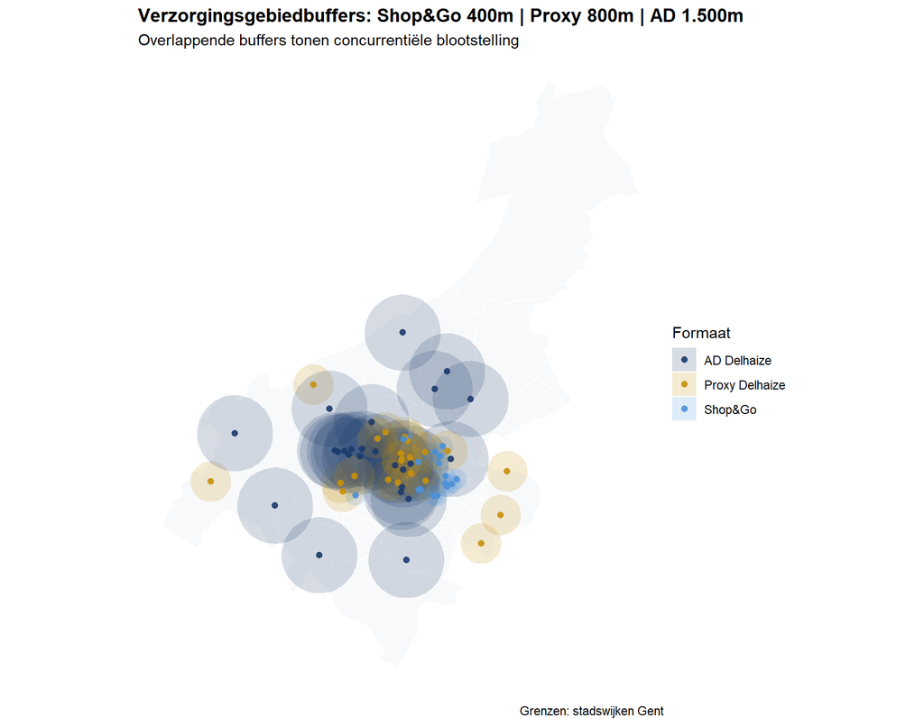

Verzorgingsgebiedbuffers per formaat (400 / 800 / 1500 m)

```r
buffers <- st_buffer(stores, stores$catchment_r_m)
buffers_wgs <- st_transform(buffers, 4326)

ggplot() +
    geom_sf(data = ghent_wgs, fill = "#F8F9FA", colour = "white", linewidth = 0.5) +
    geom_sf(data = buffers_wgs, aes(fill = format), alpha = 0.18, colour = NA) +
    geom_sf(data = stores_wgs, aes(colour = format), size = 1.8, alpha = 0.9) +
    scale_fill_manual(values = c(
        "AD Delhaize" = "#1B3A6B", "Proxy Delhaize" = "#C8900A",
        "Shop&Go" = "#4A90D9"
    ), name = "Formaat") +
    scale_colour_manual(values = c(
        "AD Delhaize" = "#1B3A6B", "Proxy Delhaize" = "#C8900A",
        "Shop&Go" = "#4A90D9"
    ), name = "Formaat") +
    labs(
        title = "Verzorgingsgebiedbuffers: Shop&Go 400m | Proxy 800m | AD 1.500m",
        subtitle = "Overlappende buffers tonen concurrentiële blootstelling",
        caption = "Grenzen: stadswijken Gent"
    ) +
    theme_void(base_size = 11) +
    theme(plot.title = element_text(face = "bold", size = 13))
```

### 3.4 Gemiddelde omzet per wijk

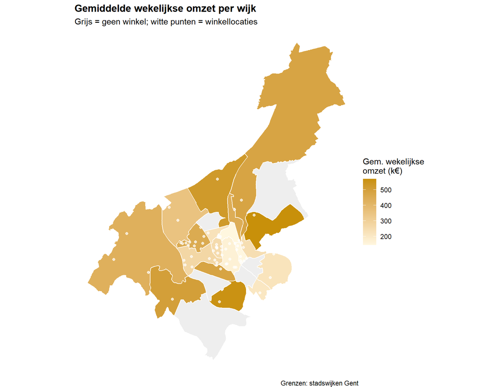

Gemiddelde wekelijkse omzet per wijk

```r
nb_turn <- stores |>
    st_drop_geometry() |>
    group_by(neighbourhood) |>
    summarise(avg_turnover = round(mean(weekly_turnover), 1), n_stores = n())

ghent_turn <- left_join(ghent_wgs, nb_turn, by = c("wijk" = "neighbourhood"))

ggplot() +
    geom_sf(data = ghent_turn, aes(fill = avg_turnover), colour = "white", linewidth = 0.4) +
    geom_sf(data = stores_wgs, colour = "white", size = 1.5, alpha = 0.7) +
    scale_fill_gradient(
        low = "#FFF7E0", high = "#C8900A",
        name = "Gem. wekelijkse\nomzet (k€)", na.value = "#EEEEEE"
    ) +
    labs(
        title = "Gemiddelde wekelijkse omzet per wijk",
        subtitle = "Grijs = geen winkel; witte punten = winkellocaties",
        caption = "Grenzen: stadswijken Gent"
    ) +
    theme_void(base_size = 11) +
    theme(plot.title = element_text(face = "bold", size = 13))
```

## 4. Beschrijvende statistiek

```r
stores |>
    st_drop_geometry() |>
    group_by(format) |>
    summarise(
        n                   = n(),
        `Gem. omzet (k€)`        = round(mean(weekly_turnover), 1),
        `SD omzet`               = round(sd(weekly_turnover), 1),
        `Gem. oppervlakte (m2)`  = round(mean(floor_area_m2)),
        `Gem. bevolkingsdichtheid` = round(mean(pop_density)),
        `Gem. inkomensindex`     = round(mean(income_index), 1),
        `Gem. concurrenten`      = round(mean(competitor_count), 1),
        `% knooppunt`            = round(mean(near_major_junction) * 100),
        `% transport`            = round(mean(near_transport_hub) * 100),
        `Gem. parking`           = round(mean(parking_spaces))
    ) |>
    kable(caption = "Beschrijvende statistiek per formaat (Gent, n=65)")
```

Beschrijvende statistiek per formaat (Gent, n=65)

| format | n | Gem. omzet (k€) | SD omzet | Gem. oppervlakte (m2) | Gem. bevolkingsdichtheid | Gem. inkomensindex | Gem. concurrenten | % knooppunt | % transport | Gem. parking |
| --- | --- | --- | --- | --- | --- | --- | --- | --- | --- | --- |
| AD Delhaize | 26 | 468.2 | 67.0 | 2088 | 3775 | 92.8 | 5.7 | 54 | 4 | 223 |
| Proxy Delhaize | 22 | 193.5 | 53.5 | 550 | 5041 | 91.4 | 8.0 | 36 | 23 | 27 |
| Shop&Go | 17 | 148.0 | 32.8 | 119 | 6877 | 94.4 | 8.8 | 18 | 59 | 3 |

## 5. MAUP: effect van ruimtelijke eenheid op coëfficiënten

Het **Modifiable Areal Unit Problem (MAUP; aanpasbaar ruimtelijk eenheidsprobleem)** is belangrijk in ruimtelijke retailanalyse. Wanneer we bevolkingsdichtheid of het aantal concurrenten per winkel meten, hangt de uitkomst sterk af van de grootte van het verzorgingsgebied. Een nauwe buffer van 400 meter in een dense centrumwijk geeft een ander beeld dan een buffer van 1.500 meter of het volledige administratieve wijkpolygoon.

Mijn werkpaper over ruimtelijke analyse-eenheden in location-choice studies documenteert dit effect systematisch. Dezelfde methodologische waarschuwing geldt ook voor retail-locatiemodellen.

```r
maup_res <- map_dfr(
    list(
        list(label = "Nauw (400 m, alle winkels)", pop_s = 1.40, comp_s = 0.55),
        list(label = "Formaatspecifieke buffer", pop_s = 1.00, comp_s = 1.00),
        list(label = "Wijkpolygoon", pop_s = 0.70, comp_s = 1.60)
    ),
    function(p) {
        d <- stores |>
            st_drop_geometry() |>
            mutate(pd = pop_density * p$pop_s, cc = competitor_count * p$comp_s)
        m <- lm(weekly_turnover ~ format + floor_area_m2 + pd + income_index +
            pct_students + pct_over65 + car_ownership + cc + retail_density +
            near_major_junction + near_transport_hub + parking_spaces, data = d)
        tidy(m, conf.int = TRUE) |>
            filter(term %in% c("pd", "cc", "income_index", "floor_area_m2")) |>
            mutate(
                spatial_unit = p$label,
                term = recode(term,
                    pd = "Bevolkingsdichtheid", cc = "Aantal concurrenten",
                    income_index = "Inkomensindex", floor_area_m2 = "Oppervlakte (m2)"
                )
            )
    }
)

maup_res |>
    select(spatial_unit, term, estimate, conf.low, conf.high, p.value) |>
    mutate(across(c(estimate, conf.low, conf.high), \(x) round(x, 3)),
        p.value = ifelse(p.value < 0.001, "<0.001", round(p.value, 3))
    ) |>
    kable(caption = "MAUP: coëfficiënten onder drie definities van ruimtelijke eenheid (Gent)")
```

MAUP: coëfficiënten onder drie definities van ruimtelijke eenheid (Gent)

| spatial_unit | term | estimate | conf.low | conf.high | p.value |
| --- | --- | --- | --- | --- | --- |
| Nauw (400 m, alle winkels) | Oppervlakte (m2) | 0.049 | 0.035 | 0.063 | <0.001 |
| Nauw (400 m, alle winkels) | Bevolkingsdichtheid | 0.009 | 0.002 | 0.016 | 0.01 |
| Nauw (400 m, alle winkels) | Inkomensindex | 1.064 | 0.244 | 1.884 | 0.012 |
| Nauw (400 m, alle winkels) | Aantal concurrenten | -23.255 | -26.133 | -20.376 | <0.001 |
| Formaatspecifieke buffer | Oppervlakte (m2) | 0.049 | 0.035 | 0.063 | <0.001 |
| Formaatspecifieke buffer | Bevolkingsdichtheid | 0.012 | 0.003 | 0.022 | 0.01 |
| Formaatspecifieke buffer | Inkomensindex | 1.064 | 0.244 | 1.884 | 0.012 |
| Formaatspecifieke buffer | Aantal concurrenten | -12.790 | -14.373 | -11.207 | <0.001 |
| Wijkpolygoon | Oppervlakte (m2) | 0.049 | 0.035 | 0.063 | <0.001 |
| Wijkpolygoon | Bevolkingsdichtheid | 0.018 | 0.004 | 0.031 | 0.01 |
| Wijkpolygoon | Inkomensindex | 1.064 | 0.244 | 1.884 | 0.012 |
| Wijkpolygoon | Aantal concurrenten | -7.994 | -8.983 | -7.004 | <0.001 |

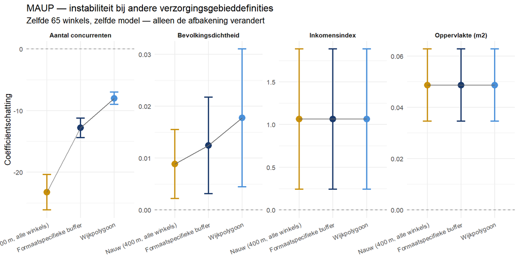

MAUP: coëfficiënt-instabiliteit over ruimtelijke eenheden

```r
maup_res |>
    mutate(spatial_unit = factor(spatial_unit,
        levels = c("Nauw (400 m, alle winkels)", "Formaatspecifieke buffer", "Wijkpolygoon")
    )) |>
    ggplot(aes(
        x = spatial_unit, y = estimate, ymin = conf.low, ymax = conf.high,
        colour = spatial_unit, group = 1
    )) +
    geom_hline(yintercept = 0, linetype = "dashed", colour = "grey55") +
    geom_errorbar(width = 0.25, linewidth = 0.85) +
    geom_point(size = 3.5) +
    geom_line(colour = "grey40", linewidth = 0.5) +
    facet_wrap(~term, scales = "free_y", ncol = 4) +
    scale_colour_manual(values = c("#C8900A", "#1B3A6B", "#4A90D9"), guide = "none") +
    labs(
        x = NULL, y = "Coëfficiëntschatting",
        title = "MAUP — instabiliteit bij andere verzorgingsgebieddefinities",
        subtitle = "Zelfde 65 winkels, zelfde model — alleen de afbakening verandert"
    ) +
    theme_minimal(base_size = 10) +
    theme(
        axis.text.x = element_text(angle = 22, hjust = 1),
        strip.text = element_text(face = "bold")
    )
```

## 6. Meervoudig regressiemodel

```r
m1 <- lm(
    weekly_turnover ~
        format + floor_area_m2 + pop_density + income_index +
        pct_students + pct_over65 + car_ownership +
        competitor_count + retail_density +
        near_major_junction + near_transport_hub + parking_spaces,
    data = stores |> st_drop_geometry()
)

tidy(m1, conf.int = TRUE) |>
    mutate(
        term = recode(term,
            "(Intercept)" = "Intercept",
            "formatProxy Delhaize" = "Formaat: Proxy (ref=AD)",
            "formatShop&Go" = "Formaat: Shop&Go (ref=AD)",
            floor_area_m2 = "Oppervlakte (m2)",
            pop_density = "Bevolkingsdichtheid",
            income_index = "Inkomensindex",
            pct_students = "Studenten (%)",
            pct_over65 = "65+ (%)",
            car_ownership = "Autobezit (%)",
            competitor_count = "Concurrenten (1 km)",
            retail_density = "Retaildichtheid",
            near_major_junction = "Nabij knooppunt",
            near_transport_hub = "Nabij transporthub",
            parking_spaces = "Parkeerplaatsen"
        ),
        sig = case_when(
            p.value < 0.001 ~ "***", p.value < 0.01 ~ "**",
            p.value < 0.05 ~ "*", p.value < 0.10 ~ ".", TRUE ~ ""
        )
    ) |>
    mutate(across(c(estimate, std.error, conf.low, conf.high), \(x)round(x, 3)),
        p.value = ifelse(p.value < 0.001, "<0.001", round(p.value, 3))
    ) |>
    kable(caption = "OLS-regressie: wekelijkse omzet ~ alle voorspellers (Gent, n=65)")
```

OLS-regressie: wekelijkse omzet ~ alle voorspellers (Gent, n=65)

| term | estimate | std.error | statistic | p.value | conf.low | conf.high | sig |
| --- | --- | --- | --- | --- | --- | --- | --- |
| Intercept | 255.845 | 55.119 | 4.6416713 | <0.001 | 145.189 | 366.501 | *** |
| Formaat: Proxy (ref=AD) | -154.674 | 15.304 | -10.1068775 | <0.001 | -185.398 | -123.950 | *** |
| Formaat: Shop&Go (ref=AD) | -210.690 | 19.390 | -10.8661742 | <0.001 | -249.616 | -171.764 | *** |
| Oppervlakte (m2) | 0.049 | 0.007 | 6.9556363 | <0.001 | 0.035 | 0.063 | *** |
| Bevolkingsdichtheid | 0.012 | 0.005 | 2.6791708 | 0.01 | 0.003 | 0.022 | ** |
| Inkomensindex | 1.064 | 0.409 | 2.6043154 | 0.012 | 0.244 | 1.884 | * |
| Studenten (%) | 0.141 | 0.751 | 0.1872814 | 0.852 | -1.368 | 1.649 |  |
| 65+ (%) | 0.464 | 0.723 | 0.6413587 | 0.524 | -0.988 | 1.916 |  |
| Autobezit (%) | -0.766 | 0.396 | -1.9336947 | 0.059 | -1.562 | 0.029 | . |
| Concurrenten (1 km) | -12.790 | 0.788 | -16.2208445 | <0.001 | -14.373 | -11.207 | *** |
| Retaildichtheid | 0.410 | 0.262 | 1.5659963 | 0.124 | -0.116 | 0.936 |  |
| Nabij knooppunt | 13.164 | 4.903 | 2.6851313 | 0.01 | 3.322 | 23.007 | ** |
| Nabij transporthub | 26.082 | 6.486 | 4.0216129 | <0.001 | 13.062 | 39.102 | *** |
| Parkeerplaatsen | 0.216 | 0.054 | 4.0184896 | <0.001 | 0.108 | 0.324 | *** |

```r
glance(m1) |>
    select(r.squared, adj.r.squared, sigma, statistic, p.value, AIC, nobs) |>
    mutate(across(where(is.numeric), \(x)round(x, 3))) |>
    kable(caption = "Model-fit statistieken")
```

Model-fit statistieken

| r.squared | adj.r.squared | sigma | statistic | p.value | AIC | nobs |
| --- | --- | --- | --- | --- | --- | --- |
| 0.99 | 0.988 | 17.088 | 407.857 | 0 | 567.681 | 65 |

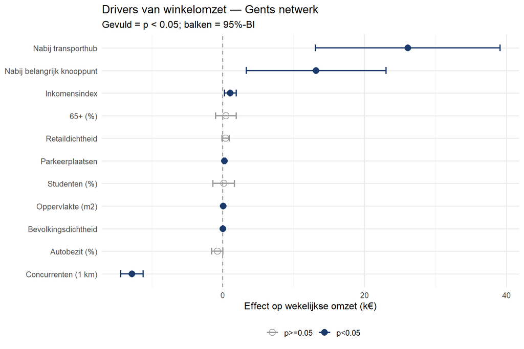

Coëfficiëntenplot

```r
tidy(m1, conf.int = TRUE) |>
    filter(!grepl("Intercept|format", term)) |>
    mutate(
        term = recode(term,
            floor_area_m2 = "Oppervlakte (m2)", pop_density = "Bevolkingsdichtheid",
            income_index = "Inkomensindex", pct_students = "Studenten (%)",
            pct_over65 = "65+ (%)", car_ownership = "Autobezit (%)",
            competitor_count = "Concurrenten (1 km)", retail_density = "Retaildichtheid",
            near_major_junction = "Nabij belangrijk knooppunt",
            near_transport_hub = "Nabij transporthub", parking_spaces = "Parkeerplaatsen"
        ),
        sig = p.value < 0.05
    ) |>
    ggplot(aes(
        x = estimate, xmin = conf.low, xmax = conf.high,
        y = reorder(term, estimate), colour = sig, shape = sig
    )) +
    geom_vline(xintercept = 0, linetype = "dashed", colour = "grey55") +
    geom_errorbarh(height = 0.3, linewidth = 0.8) +
    geom_point(size = 3.5) +
    scale_colour_manual(
        values = c("grey60", "#1B3A6B"),
        labels = c("p>=0.05", "p<0.05"), name = ""
    ) +
    scale_shape_manual(values = c(1, 16), labels = c("p>=0.05", "p<0.05"), name = "") +
    labs(
        x = "Effect op wekelijkse omzet (k€)", y = NULL,
        title = "Drivers van winkelomzet — Gents netwerk",
        subtitle = "Gevuld = p < 0.05; balken = 95%-BI"
    ) +
    theme_minimal(base_size = 12) +
    theme(legend.position = "bottom")
```

## 7. Impact van concurrentie en bereikbaarheid

```r
bc <- coef(m1)["competitor_count"]
bj <- coef(m1)["near_major_junction"]
bt <- coef(m1)["near_transport_hub"]

tibble(
    Scenario = c(
        "1 extra concurrent (1 km)", "2 extra concurrenten",
        "3 extra concurrenten", "Nabij belangrijk knooppunt", "Nabij transporthub",
        "Knooppunt + transporthub"
    ),
    `Wekelijks (k€)` = round(c(bc, 2 * bc, 3 * bc, bj, bt, bj + bt), 1),
    `Jaarlijks (k€)` = round(c(bc, 2 * bc, 3 * bc, bj, bt, bj + bt) * 52, 0)
) |>
    kable(caption = "Omzetimpact: concurrentie en bereikbaarheid (Gents model)")
```

Omzetimpact: concurrentie en bereikbaarheid (Gents model)

| Scenario | Wekelijks (k€) | Jaarlijks (k€) |
| --- | --- | --- |
| 1 extra concurrent (1 km) | -12.8 | -665 |
| 2 extra concurrenten | -25.6 | -1330 |
| 3 extra concurrenten | -38.4 | -1995 |
| Nabij belangrijk knooppunt | 13.2 | 685 |
| Nabij transporthub | 26.1 | 1356 |
| Knooppunt + transporthub | 39.2 | 2041 |

## 8. Scenario: drie hypothetische nieuwe Gentse locaties

```r
new_locs <- tibble(
    Location = c(
        "A: Dampoort (binnenstedelijk oost)", "B: Mariakerke (suburbaan noordwest)",
        "C: Sint-Amandsberg (residentieel oost)"
    ),
    format = c("Proxy Delhaize", "AD Delhaize", "Proxy Delhaize"),
    floor_area_m2 = c(520, 2600, 480),
    pop_density = c(5200, 1100, 2400),
    income_index = c(95, 110, 101),
    pct_students = c(18, 5, 8),
    pct_over65 = c(17, 23, 20),
    car_ownership = c(61, 85, 76),
    competitor_count = c(3, 1, 2),
    retail_density = c(72, 15, 30),
    near_major_junction = c(0, 1, 1),
    near_transport_hub = c(1, 0, 0),
    parking_spaces = c(12, 290, 45)
)

preds <- predict(m1, newdata = new_locs, interval = "prediction", level = 0.90)

new_locs |>
    bind_cols(as_tibble(preds)) |>
    select(Location, format,
        `Voorspeld (k€/week)` = fit, `90% PI laag` = lwr, `90% PI hoog` = upr
    ) |>
    mutate(across(where(is.numeric), \(x)round(x, 1))) |>
    kable(caption = "Voorspelde wekelijkse omzet — drie hypothetische Gentse locaties (90% PI)")
```

Voorspelde wekelijkse omzet — drie hypothetische Gentse locaties (90% PI)

| Location | format | Voorspeld (k€/week) | 90% PI laag | 90% PI hoog |
| --- | --- | --- | --- | --- |
| A: Dampoort (binnenstedelijk oost) | Proxy Delhaize | 275.7 | 243.7 | 307.6 |
| B: Mariakerke (suburbaan noordwest) | AD Delhaize | 528.4 | 496.4 | 560.5 |
| C: Sint-Amandsberg (residentieel oost) | Proxy Delhaize | 223.6 | 193.1 | 254.0 |

## 9. Belangrijkste bevindingen

```r
tibble(
    Variabele = c(
        "Oppervlakte (m2)", "Bevolkingsdichtheid", "Inkomensindex",
        "Studenten (%)", "65+ (%)", "Autobezit (%)",
        "Concurrenten (1 km)", "Retaildichtheid", "Nabij knooppunt",
        "Nabij transporthub", "Parkeerplaatsen"
    ),
    Richting = c("+", "+", "+", "+", "+", "-", "-", "+", "+", "+", "+"),
    `MAUP-gevoeligheid` = c(
        "Geen", "Hoog", "Matig", "Hoog", "Laag", "Laag",
        "Hoog", "Hoog", "Geen", "Geen", "Geen"
    ),
    Interpretatie = c(
        "Grotere winkel trekt klanten uit ruimer gebied; breder assortiment",
        "Dichter verzorgingsgebied = grotere potentiële klantenbasis",
        "Hoger inkomen = grotere gemiddelde winkelmand",
        "Studenten: frequente, kleinere en prijsgevoelige aankopen",
        "Ouderen: loyale en frequente klanten",
        "Hoog autobezit = risico op shopping buiten de buurt",
        "Elke concurrent binnen 1 km verlaagt de verwachte omzet",
        "Complementaire winkels stimuleren passage",
        "Wegbereikbaarheid ondersteunt impulsaankopen met de auto",
        "Pendelaars- en lunchverkeer",
        "Parking ondersteunt autogebonden weekboodschappen"
    )
) |>
    kable(caption = "Samenvatting: richting, MAUP-gevoeligheid en interpretatie per driver")
```

Samenvatting: richting, MAUP-gevoeligheid en interpretatie per driver

[output not shown]

## 10. Methodologische nota

Deze demo gebruikt **echte Gentse wijkgrenzen** (officiële stadswijken-shapefile, 25 polygonen). Winkels worden gesimuleerd via willekeurige punten, gewogen naar bevolkingsdichtheid. De analytische pipeline omvat:

- CRS-transformatie naar Belgische Lambert 72 voor afstandsberekeningen
- Concurrentiemeting op basis van de feitelijke afstandsmatrix tussen winkels
- Drie ruimtelijke niveaus voor de MAUP-demonstratie

In productie kan dezelfde pipeline synthetische omzet vervangen door POS-data en synthetische winkellocaties door echte coördinaten.

| Upgrade | Bron |
| --- | --- |
| Winkelcoördinaten | Delhaize intern |
| Werkelijke omzet | POS / ERP-systemen |
| Bevolking per verzorgingsgebied | Statbel sectorstatistieken |
| Concurrentielocaties | OSM / Nielsen / interne audit |
| Werkelijk inkomen per zone | Statbel fiscale statistieken |

*Winkellocaties, omzetcijfers en socio-economische parameters zijn synthetisch. Wijkgrenzen: stadswijken Gent (officiële shapefile). Analyse geproduceerd in R (sf, ggplot2, rmarkdown).*